# Estadística y Probabilidades I

##### **Dependencia de Magnitud X Profundidad**

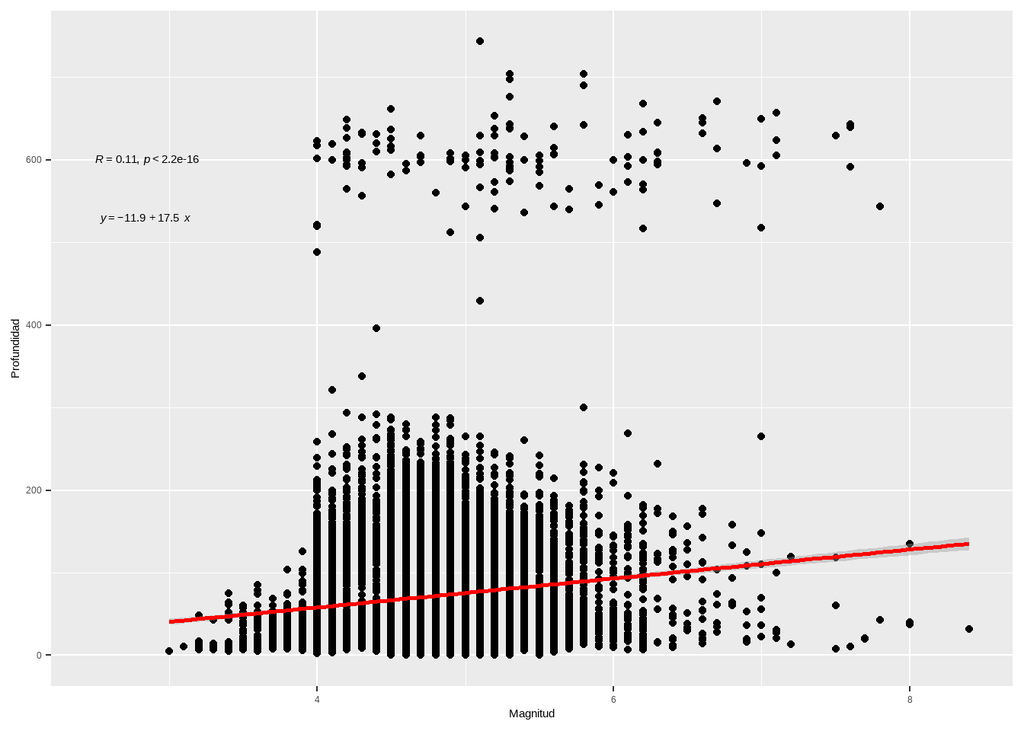

Para nuestros datos podemos identificar algunas dependencias de variables. Para la primera se busca hallar la profundidad de un sismo en función de la magnitud del mismo tendríamos a nuestra variable dependiente a la profundidad y variable independiente a la magnitud. A simple vista se ve que si hay dependencia de entre mayor magnitud mayor profundidad. Se muestra una regresión y su correlación es igual a 0.11 que significa una correlación positiva muy baja, es decir, no presenta una gran dependencia en la gráfica se aprecia como la regresión lineal solo aumenta en una pequeña proporción.

##### **Dependencia de Longitud X Profundidad**

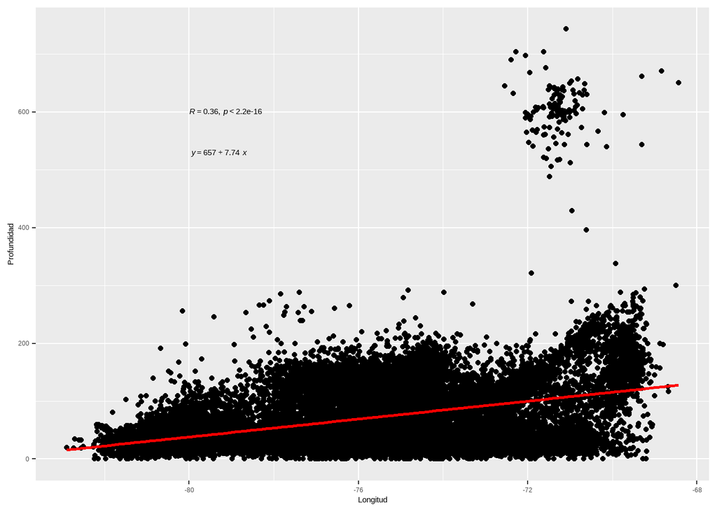

Para esta dependencia tenemos la profundidad de un sismo en función de la longitud así tendremos la longitud como variable independiente y la profundidad como variable dependiente. Asi podemos apreciar que a mas al este del peru la profundidad de los sismos es mayor. Se muestra una regresión y su correlación es igual a 0.36 que significa una correlación positiva baja, es decir, no presenta una gran dependencia. En la gráfica se aprecia una mayor regresión lineal por lo cual se muestra una mayor dependencia.

##### **Dependencia de Años X Magnitud**

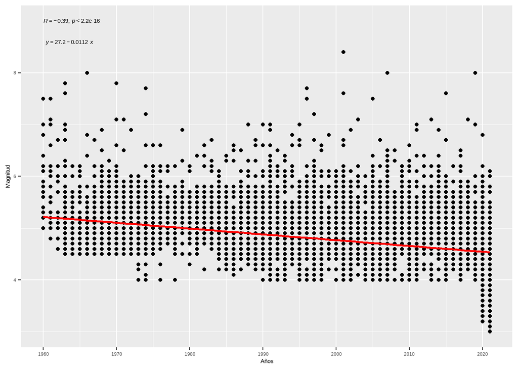

Para esta variables tenemos a los años como variable independiente y a la magnitud como variable dependiente que muestra una dependencia negativa, es decir, que en el paso del tiempo los sismos han ido teniendo una menor magnitud. Tiene una correlación de -0.39 que significa una correlación negativa baja.

##### **Dependencia de Longitud X Magnitud**

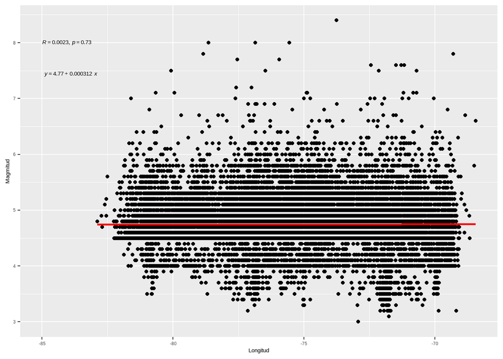

#### **Predicciones del comportamiento de variables**

- Para la variable **magnitud**, conforme avancen los años se va atender a aumentar la frecuencia del registro de sismos, especialmente de los sismos de **muy baja magnitud**.
- Para las variables **magnitud y profundidad**, podemos predecir con muy baja precisión que en caso ocurra un sismo en una **zona este** del país, esta será de mayor profundidad que en caso ocurra uno en la zona oeste.
- No podemos predecir qué tipo de sismo será el siguiente en ocurrir, lo más probable es que ocurra uno de magnitud entre 4 y 5. Pero podemos decir también con muy baja precisión, que **si** el siguiente sismo es de baja magnitud, será también **superficial**, y si es de gran magnitud, será **profundo.**

#### **Reflexión y conclusiones**

**Determinar la susceptibilidad física ante sismos de diferentes zonas del Perú de acuerdo a la frecuencia, profundidad y magnitud sísmica, para poder ser usado en el ordenamiento territorial.**

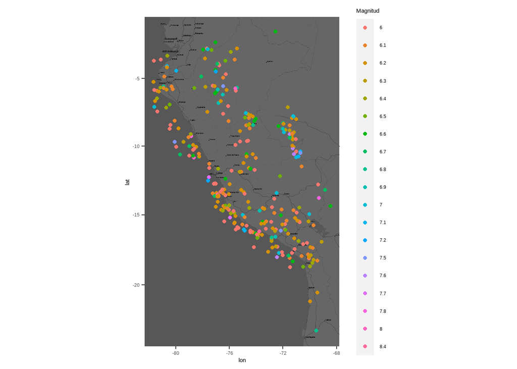

Como podemos ver los sismos de mayor magnitud, es decir, los que traen mayor desastre se encuentran en la costa y selva del país. Lo que muestra que la sierra es en donde ocurren menos sismos de alto riesgo para la población, y los que ocurren en esta parte del país no son tan destructivos como los de mayor magnitud, por ello se le considera la zona mas segura para los ciudadanos. Por lo tanto, deben existir mayores políticas de manejo ante sismos en la zona costa y selva.

**Identificar irregularidades y tendencias entre latitud, longitud, magnitud, profundidad, fecha, hora, variables directamente vinculadas a los sismos en la línea de tiempo desde el año 1960 en el Perú.**

- Analizar la frecuencia de los sismos en diferentes zonas del Perú:

La base de datos del IGP muestra como ha ido en aumento el registro de sismos con el pasar del tiempo como ya lo vimos en el histograma de variable año. Esto no necesariamente significa que la frecuencia de sismos ha aumentado y podría deberse a cambios en la forma de registro de sismos.

- Analizar la magnitud de los sismos de las diferentes zonas del Perú.

- Analizar la profundidad de los sismos de las diferentes zonas del Perú.

Para este resultado tomamos una nueva variable de rango que se dividió en superficial, intermedia y profunda. Dando como resultado que mas de la mitad de nuestra muestra es superficial siendo esta la zona de mayor frecuencia de sismos y terminando con que los sismos mas profundos se encuentran en el este.

### **Bibliografía**

- Datos de CENTRO SISMOLOGICO NACIONAL (CENSIS). Consultado el 05 de noviembre del 2021 en https://ultimosismo.igp.gob.pe/inicio
- Mapa de Peligro Sísmico para el Perú. (2014). Perú. INSTITUTO GEOFÍSICO DEL PERÚ. Recuperado de http://sigrid.cenepred.gob.pe/docs/PARA%20PUBLICAR/IGP/Mapa_Peligro_Sismico_Peru_2015_Version_Preliminar.pdf#:~:text=3.%2D%20SISMICIDAD%20EN%20PER%C3%9A,-La%20sismicidad%20en&text=Los%20sismos%20han%20sido%20diferenciados,(h%3E351%20km)  
  -Entrevista a Presidente Ejecutivo del IGP (2019) - https://www.gob.pe/institucion/igp/noticias/71381-mas-de-500-sismos-reporto-el-instituto-geofisico-del-peru-en-el-2019